# Introduction to Machine Learning with scikit-learn

## Lab 2: Classification

The goal of this lab session is to discover a few classification tools from scikit-learn.

## Classification of generated data

### Data generation

We will start by generating a 2D training set composed of two classes (labelled 0 and 1).

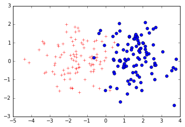

```python
%matplotlib inline
import numpy as np

# class '0'
features_0 = [-1.5, 0] + np.random.randn(100, 2)
labels_0 = np.zeros(100)

# class '1'
features_1 = [+1.5, 0] + np.random.randn(100, 2)
labels_1 = np.ones(100)

# show the training set with matplotlib
import matplotlib.pyplot as plt

plt.figure()
plt.plot(features_0[:, 0], features_0[:, 1], 'r+') # r+ means red pluses
plt.plot(features_1[:, 0], features_1[:, 1], 'bo') # bo means blue circles
```

In the following cell, we are just defining what is needed to train the classifier and display it

```python
# Merge the two classes in a single set
features = np.concatenate((features_0, features_1)) # for features
labels = np.concatenate((labels_0, labels_1)) # for labels

# Define a mesh grid on which we will test the classifiers
mesh_size = 0.1
x_min, x_max = features[:, 0].min() - 1, features[:, 0].max() + 1
y_min, y_max = features[:, 1].min() - 1, features[:, 1].max() + 1
xx, yy = np.meshgrid(np.arange(x_min, x_max, mesh_size),
                     np.arange(y_min, y_max, mesh_size))

# Define a function that shows the
def show_results(classifier, title):
    Z = classifier.predict(np.c_[xx.ravel(), yy.ravel()])
    Z = Z.reshape(xx.shape)
    plt.contourf(xx, yy, Z, cmap=plt.cm.Paired, alpha=0.8)
    plt.scatter(features[:, 0], features[:, 1], c=labels, cmap=plt.cm.Paired)
    # c=labels means that the color will correspond to the label
    # cmap=plt.cm.Paired is a colormap less agressive than the blue/red default color (which is somewhat flashy)
    plt.title(title)
```

### Binary Support Vector Machines

We will start with the support vector machine (SVM) classifier.

```python
# in scikit-learn, the SVM classifier is referred to as SVC (Support Vector Classifier)
from sklearn.svm import SVC
```

#### Linear kernel

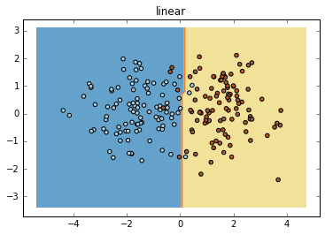

```python
my_C = 10 # the soft-margin trade-off parameter
my_kernel = 'linear' # the kernel
my_linear_classifier = SVC(kernel = my_kernel, C = my_C).fit(features, labels) # train the classifier
show_results(my_linear_classifier, my_kernel) # display the results
```

#### Gaussian (or RBF for radial basis function) kernel

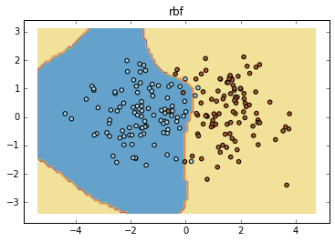

```python
my_kernel = 'rbf'
my_gamma = 0.5
my_gaussian_classifier = SVC(kernel = my_kernel, C = my_C, gamma = my_gamma).fit(features, labels)
show_results(my_gaussian_classifier, my_kernel)
```

#### Polynomial kernel

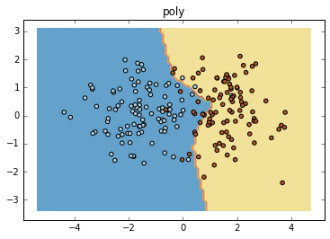

```python
my_kernel = 'poly'
my_degree = 5
my_polynomial_classifier = SVC(kernel = my_kernel, C = my_C, degree = my_degree).fit(features, labels)
show_results(my_polynomial_classifier, my_kernel)
```

### Decision Trees

In scikit-learn, decision trees classifier are simply referred to as DecisionTreeClassifier.

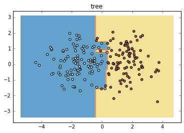

```python
from sklearn.tree import DecisionTreeClassifier
my_tree_classifier = DecisionTreeClassifier().fit(features, labels)
show_results(my_tree_classifier, 'tree')
```

### Model evaluation

There are several ways to evaluate a model without having to visualize the data. The accuracy is the simplest of them: it is the proportion of well classified samples. Standard evaluation metrics can be found in sklearn.metrics.

Note: In this lab session, we won't detail much the model evaluation. There will be a session about entirely dedicated to model evaluation and selection.

```python
from sklearn import metrics

predicted_labels = my_linear_classifier.predict(features)
print "accuracy of the linear classifier: ", metrics.accuracy_score(labels, predicted_labels)
predicted_labels = my_gaussian_classifier.predict(features)
print "accuracy of the rbf classifier: ", metrics.accuracy_score(labels, predicted_labels)
predicted_labels = my_polynomial_classifier.predict(features)
print "accuracy of the polynomial classifier: ", metrics.accuracy_score(labels, predicted_labels)
```

```
accuracy of the linear classifier:  0.955
accuracy of the rbf classifier:  0.965
accuracy of the polynomial classifier:  0.915
```

## Multiclass classification

The previous case showed a binary classification example. As we saw during the lecture, classification can be made in the multiclass scenario (3 or more classes).

Here again, we will generate data (3 classes labeled '0', '1' and '2').

```python
# Generate the data
features_0 = [-2.0, 0] + np.random.randn(100, 2)
features_1 = [+2.0, 0] + np.random.randn(100, 2)
features_2 = [0, +2.0] + np.random.randn(100, 2)
labels_0 = np.zeros(100)
labels_1 = np.ones(100)
labels_2 = 2 * np.ones(100)

# Merge the data
features = np.concatenate((features_0, features_1, features_2))
labels = np.concatenate((labels_0, labels_1, labels_2))

# Re-define the meshgrid
mesh_size = 0.1
x_min, x_max = features[:, 0].min() - 1, features[:, 0].max() + 1
y_min, y_max = features[:, 1].min() - 1, features[:, 1].max() + 1
xx, yy = np.meshgrid(np.arange(x_min, x_max, mesh_size),
                     np.arange(y_min, y_max, mesh_size))
```

### Support Vector machines

There are 2 main ways to extend a binary classifier (such as the SVM) to the multiclass case: "one versus one" and "one versus all" (or "one versus rest").

#### One versus one classification

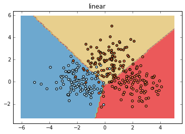

```python
# feel free to play with the parameters (kernel, C, gamma, degree).
my_C = 1.0
my_kernel = 'linear'
my_linear_classifier = SVC(kernel = my_kernel, C = my_C, decision_function_shape = 'ovo').fit(features, labels)
show_results(my_linear_classifier, my_kernel)
```

#### One versus all (rest) classification

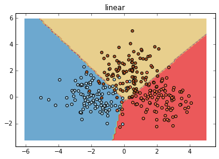

```python
my_linear_classifier = SVC(kernel = my_kernel, C = my_C, decision_function_shape = 'ovr').fit(features, labels)
show_results(my_linear_classifier, my_kernel)
```

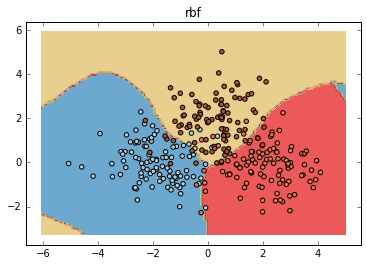

```python
my_kernel = 'rbf'
my_gamma = 0.5
my_gaussian_classifier = SVC(kernel = my_kernel, C = my_C, gamma = my_gamma).fit(features, labels)
show_results(my_gaussian_classifier, my_kernel)
```

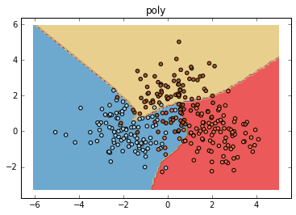

```python
my_kernel = 'poly'
my_degree = 5
my_polynomial_classifier = SVC(kernel = my_kernel, C = my_C, degree = my_degree).fit(features, labels)
show_results(my_polynomial_classifier, my_kernel)
```

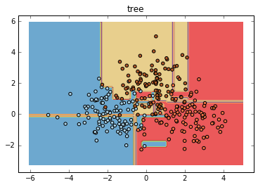

```python
from sklearn.tree import DecisionTreeClassifier
my_tree_classifier = DecisionTreeClassifier().fit(features, labels)
show_results(my_tree_classifier, 'tree')
```

```python
from sklearn.tree import export_graphviz
export_graphviz(my_tree_classifier, out_file='tree.dot')

# The following is OS dependent
# Ubuntu (you'll need to install GraphViz: 'apt-get install graphviz')
# PS/PDF format:
!dot -Tps tree.dot -o tree.ps
!evince tree.ps
# MacOS: You'll also need GraphViz: 'brew install graphviz'
# !dot -Tpng tree.dot -o tree.png
# !open tree.png # works with MacOS

# Note: The "!" at the beginning of a Python instruction means that what follow will be run as if you were in a terminal.
# (Hence, these commands depend on your OS and what's installed on it).
```

## On an imported dataset

### The Iris dataset

In this section, we will apply the classification algorithms we have seen to a standard dataset: The Iris dataset (https://en.wikipedia.org/wiki/Iris_flower_data_set).

It is a really small dataset which can be loaded this way:

```python
from sklearn import datasets
iris = datasets.load_iris()
```

The iris object has several fields:

```python
print iris
```

```
{'target_names': array(['setosa', 'versicolor', 'virginica'],
      dtype='|S10'), 'data': array([[ 5.1,  3.5,  1.4,  0.2],
       [ 4.9,  3. ,  1.4,  0.2],
       [ 4.7,  3.2,  1.3,  0.2],
       [ 4.6,  3.1,  1.5,  0.2],
       [ 5. ,  3.6,  1.4,  0.2],
       [ 5.4,  3.9,  1.7,  0.4],
       [ 4.6,  3.4,  1.4,  0.3],
       [ 5. ,  3.4,  1.5,  0.2],
       [ 4.4,  2.9,  1.4,  0.2],
       [ 4.9,  3.1,  1.5,  0.1],
       [ 5.4,  3.7,  1.5,  0.2],
       [ 4.8,  3.4,  1.6,  0.2],
       [ 4.8,  3. ,  1.4,  0.1],
       [ 4.3,  3. ,  1.1,  0.1],
       [ 5.8,  4. ,  1.2,  0.2],
       [ 5.7,  4.4,  1.5,  0.4],
       [ 5.4,  3.9,  1.3,  0.4],
       [ 5.1,  3.5,  1.4,  0.3],
       [ 5.7,  3.8,  1.7,  0.3],
       [ 5.1,  3.8,  1.5,  0.3],
       [ 5.4,  3.4,  1.7,  0.2],
       [ 5.1,  3.7,  1.5,  0.4],
       [ 4.6,  3.6,  1. ,  0.2],
       [ 5.1,  3.3,  1.7,  0.5],
       [ 4.8,  3.4,  1.9,  0.2],
       [ 5. ,  3. ,  1.6,  0.2],
       [ 5. ,  3.4,  1.6,  0.4],
       [ 5.2,  3.5,  1.5,  0.2],
       [ 5.2,  3.4,  1.4,  0.2],
       [ 4.7,  3.2,  1.6,  0.2],
       [ 4.8,  3.1,  1.6,  0.2],
       [ 5.4,  3.4,  1.5,  0.4],
       [ 5.2,  4.1,  1.5,  0.1],
       [ 5.5,  4.2,  1.4,  0.2],
       [ 4.9,  3.1,  1.5,  0.1],
       [ 5. ,  3.2,  1.2,  0.2],
       [ 5.5,  3.5,  1.3,  0.2],
       [ 4.9,  3.1,  1.5,  0.1],
       [ 4.4,  3. ,  1.3,  0.2],
```

[output cut: 102 more lines]

```
       [ 6.9,  3.1,  5.1,  2.3],
       [ 5.8,  2.7,  5.1,  1.9],
       [ 6.8,  3.2,  5.9,  2.3],
       [ 6.7,  3.3,  5.7,  2.5],
       [ 6.7,  3. ,  5.2,  2.3],
       [ 6.3,  2.5,  5. ,  1.9],
       [ 6.5,  3. ,  5.2,  2. ],
       [ 6.2,  3.4,  5.4,  2.3],
       [ 5.9,  3. ,  5.1,  1.8]]), 'target': array([0, 0, 0, 0, 0, 0, 0, 0, 0, 0, 0, 0, 0, 0, 0, 0, 0, 0, 0, 0, 0, 0, 0,
       0, 0, 0, 0, 0, 0, 0, 0, 0, 0, 0, 0, 0, 0, 0, 0, 0, 0, 0, 0, 0, 0, 0,
       0, 0, 0, 0, 1, 1, 1, 1, 1, 1, 1, 1, 1, 1, 1, 1, 1, 1, 1, 1, 1, 1, 1,
       1, 1, 1, 1, 1, 1, 1, 1, 1, 1, 1, 1, 1, 1, 1, 1, 1, 1, 1, 1, 1, 1, 1,
       1, 1, 1, 1, 1, 1, 1, 1, 2, 2, 2, 2, 2, 2, 2, 2, 2, 2, 2, 2, 2, 2, 2,
       2, 2, 2, 2, 2, 2, 2, 2, 2, 2, 2, 2, 2, 2, 2, 2, 2, 2, 2, 2, 2, 2, 2,
       2, 2, 2, 2, 2, 2, 2, 2, 2, 2, 2, 2]), 'DESCR': 'Iris Plants Database\n\nNotes\n-----\nData Set Characteristics:\n    :Number of Instances: 150 (50 in each of three classes)\n    :Number of Attributes: 4 numeric, predictive attributes and the class\n    :Attribute Information:\n        - sepal…
```

We can show the dataset description:

```python
print iris.DESCR
```

```
Iris Plants Database

Notes
-----
Data Set Characteristics:
    :Number of Instances: 150 (50 in each of three classes)
    :Number of Attributes: 4 numeric, predictive attributes and the class
    :Attribute Information:
        - sepal length in cm
        - sepal width in cm
        - petal length in cm
        - petal width in cm
        - class:
                - Iris-Setosa
                - Iris-Versicolour
                - Iris-Virginica
    :Summary Statistics:

    ============== ==== ==== ======= ===== ====================
                    Min  Max   Mean    SD   Class Correlation
    ============== ==== ==== ======= ===== ====================
    sepal length:   4.3  7.9   5.84   0.83    0.7826
    sepal width:    2.0  4.4   3.05   0.43   -0.4194
    petal length:   1.0  6.9   3.76   1.76    0.9490  (high!)
    petal width:    0.1  2.5   1.20  0.76     0.9565  (high!)
    ============== ==== ==== ======= ===== ====================

    :Missing Attribute Values: None
    :Class Distribution: 33.3% for each of 3 classes.
    :Creator: R.A. Fisher
    :Donor: Michael Marshall (MARSHALL%PLU@io.arc.nasa.gov)
    :Date: July, 1988

This is a copy of UCI ML iris datasets.
http://archive.ics.uci.edu/ml/datasets/Iris

The famous Iris database, first used by Sir R.A Fisher

This is perhaps the best known database to be found in the
pattern recognition literature.  Fisher's paper is a classic in the field and
is referenced frequently to this day.  (See Duda & Hart, for example.)  The
data set contains 3 classes of 50 instances each, where each class refers to a
type of iris plant.  One class is linearly separable from the other 2; the
latter are NOT linearly separable from each other.

References
----------
   - Fisher,R.A. "The use of multiple measurements in taxonomic problems"
     Annual Eugenics, 7, Part II, 179-188 (1936); also in "Contributions to
     Mathematical Statistics" (John Wiley, NY, 1950).
   - Duda,R.O., & Hart,P.E. (1973) Pattern Classification and Scene Analysis.
     (Q327.D83) John Wiley & Sons.  ISBN 0-471-22361-1.  See page 218.
   - Dasarathy, B.V. (1980) "Nosing Around the Neighborhood: A New System
     Structure and Classification Rule for Recognition in Partially Exposed
     Environments".  IEEE Transactions on Pattern Analysis and Machine
     Intelligence, Vol. PAMI-2, No. 1, 67-71.
   - Gates, G.W. (1972) "The Reduced Nearest Neighbor Rule".  IEEE Transactions
     on Information Theory, May 1972, 431-433.
   - See also: 1988 MLC Proceedings, 54-64.  Cheeseman et al"s AUTOCLASS II
     conceptual clustering system finds 3 classes in the data.
   - Many, many more ...
```

The fields that interest us the most concern the features (data and feature_names), the labels (target and target_names).

```python
features = iris.data
print features
```

```
[[ 5.1  3.5  1.4  0.2]
 [ 4.9  3.   1.4  0.2]
 [ 4.7  3.2  1.3  0.2]
 [ 4.6  3.1  1.5  0.2]
 [ 5.   3.6  1.4  0.2]
 [ 5.4  3.9  1.7  0.4]
 [ 4.6  3.4  1.4  0.3]
 [ 5.   3.4  1.5  0.2]
 [ 4.4  2.9  1.4  0.2]
 [ 4.9  3.1  1.5  0.1]
 [ 5.4  3.7  1.5  0.2]
 [ 4.8  3.4  1.6  0.2]
 [ 4.8  3.   1.4  0.1]
 [ 4.3  3.   1.1  0.1]
 [ 5.8  4.   1.2  0.2]
 [ 5.7  4.4  1.5  0.4]
 [ 5.4  3.9  1.3  0.4]
 [ 5.1  3.5  1.4  0.3]
 [ 5.7  3.8  1.7  0.3]
 [ 5.1  3.8  1.5  0.3]
 [ 5.4  3.4  1.7  0.2]
 [ 5.1  3.7  1.5  0.4]
 [ 4.6  3.6  1.   0.2]
 [ 5.1  3.3  1.7  0.5]
 [ 4.8  3.4  1.9  0.2]
 [ 5.   3.   1.6  0.2]
 [ 5.   3.4  1.6  0.4]
 [ 5.2  3.5  1.5  0.2]
 [ 5.2  3.4  1.4  0.2]
 [ 4.7  3.2  1.6  0.2]
 [ 4.8  3.1  1.6  0.2]
 [ 5.4  3.4  1.5  0.4]
 [ 5.2  4.1  1.5  0.1]
 [ 5.5  4.2  1.4  0.2]
 [ 4.9  3.1  1.5  0.1]
 [ 5.   3.2  1.2  0.2]
 [ 5.5  3.5  1.3  0.2]
 [ 4.9  3.1  1.5  0.1]
 [ 4.4  3.   1.3  0.2]
 [ 5.1  3.4  1.5  0.2]
```

[output cut: 95 more lines]

```
 [ 7.7  3.   6.1  2.3]
 [ 6.3  3.4  5.6  2.4]
 [ 6.4  3.1  5.5  1.8]
 [ 6.   3.   4.8  1.8]
 [ 6.9  3.1  5.4  2.1]
 [ 6.7  3.1  5.6  2.4]
 [ 6.9  3.1  5.1  2.3]
 [ 5.8  2.7  5.1  1.9]
 [ 6.8  3.2  5.9  2.3]
 [ 6.7  3.3  5.7  2.5]
 [ 6.7  3.   5.2  2.3]
 [ 6.3  2.5  5.   1.9]
 [ 6.5  3.   5.2  2. ]
 [ 6.2  3.4  5.4  2.3]
 [ 5.9  3.   5.1  1.8]]
```

```python
features_names = iris.feature_names
print features_names
```

```
['sepal length (cm)', 'sepal width (cm)', 'petal length (cm)', 'petal width (cm)']
```

```python
labels = iris.target
print labels
```

```
[0 0 0 0 0 0 0 0 0 0 0 0 0 0 0 0 0 0 0 0 0 0 0 0 0 0 0 0 0 0 0 0 0 0 0 0 0
 0 0 0 0 0 0 0 0 0 0 0 0 0 1 1 1 1 1 1 1 1 1 1 1 1 1 1 1 1 1 1 1 1 1 1 1 1
 1 1 1 1 1 1 1 1 1 1 1 1 1 1 1 1 1 1 1 1 1 1 1 1 1 1 2 2 2 2 2 2 2 2 2 2 2
 2 2 2 2 2 2 2 2 2 2 2 2 2 2 2 2 2 2 2 2 2 2 2 2 2 2 2 2 2 2 2 2 2 2 2 2 2
 2 2]
```

```python
label_names = iris.target_names
print label_names
```

```
['setosa' 'versicolor' 'virginica']
```

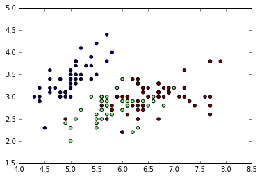

```python
plt.figure()
plt.scatter(features[:, 0], features[:, 1], c=labels)
```

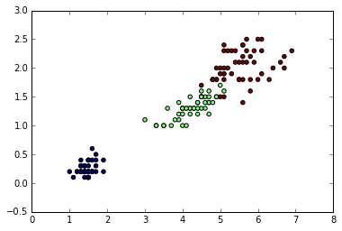

```python
plt.figure()
plt.scatter(features[:, 2], features[:, 3], c=labels)
```

```python
C = 1.0
my_linear_classifier = SVC(kernel='linear', C=C).fit(features, labels)
```

```python
predicted_labels = my_linear_classifier.predict(features)
print "accuracy of the linear classifier: ", metrics.accuracy_score(labels, predicted_labels)
```

```
accuracy of the linear classifier:  0.993333333333
```

```python
from sklearn.cross_validation import train_test_split
# or
# from sklearn.model_selection import train_test_split
features_train, features_test, labels_train, labels_test = train_test_split(features, labels, test_size = 0.5)
```

```python
my_linear_classifier = SVC(kernel='linear', C=C).fit(features_train, labels_train)
```

```python
predicted_labels_train = my_linear_classifier.predict(features_train)
print "accuracy of the linear classifier: ", metrics.accuracy_score(labels_train, predicted_labels_train)
predicted_labels_test = my_linear_classifier.predict(features_test)
print "accuracy of the linear classifier: ", metrics.accuracy_score(labels_test, predicted_labels_test)
```

```
accuracy of the linear classifier:  0.96
accuracy of the linear classifier:  1.0
```

### The digits dataset

There is another classification dataset available out-of-the-box from sklearn. It is the digits dataset.

```python
from sklearn.datasets import load_digits
digits = load_digits()
```

```python
print digits.DESCR
```

```
Optical Recognition of Handwritten Digits Data Set
===================================================

Notes
-----
Data Set Characteristics:
    :Number of Instances: 5620
    :Number of Attributes: 64
    :Attribute Information: 8x8 image of integer pixels in the range 0..16.
    :Missing Attribute Values: None
    :Creator: E. Alpaydin (alpaydin '@' boun.edu.tr)
    :Date: July; 1998

This is a copy of the test set of the UCI ML hand-written digits datasets
http://archive.ics.uci.edu/ml/datasets/Optical+Recognition+of+Handwritten+Digits

The data set contains images of hand-written digits: 10 classes where
each class refers to a digit.

Preprocessing programs made available by NIST were used to extract
normalized bitmaps of handwritten digits from a preprinted form. From a
total of 43 people, 30 contributed to the training set and different 13
to the test set. 32x32 bitmaps are divided into nonoverlapping blocks of
4x4 and the number of on pixels are counted in each block. This generates
an input matrix of 8x8 where each element is an integer in the range
0..16. This reduces dimensionality and gives invariance to small
distortions.

For info on NIST preprocessing routines, see M. D. Garris, J. L. Blue, G.
T. Candela, D. L. Dimmick, J. Geist, P. J. Grother, S. A. Janet, and C.
L. Wilson, NIST Form-Based Handprint Recognition System, NISTIR 5469,
1994.

References
----------
  - C. Kaynak (1995) Methods of Combining Multiple Classifiers and Their
    Applications to Handwritten Digit Recognition, MSc Thesis, Institute of
    Graduate Studies in Science and Engineering, Bogazici University.
  - E. Alpaydin, C. Kaynak (1998) Cascading Classifiers, Kybernetika.
  - Ken Tang and Ponnuthurai N. Suganthan and Xi Yao and A. Kai Qin.
    Linear dimensionalityreduction using relevance weighted LDA. School of
    Electrical and Electronic Engineering Nanyang Technological University.
    2005.
  - Claudio Gentile. A New Approximate Maximal Margin Classification
    Algorithm. NIPS. 2000.
```

```python
print digits.target_names
```

```
[0 1 2 3 4 5 6 7 8 9]
```

```python
features = digits.data
labels = digits.target
images = digits.images
```

```python
print images
```

```
[[[  0.   0.   5. ...,   1.   0.   0.]
  [  0.   0.  13. ...,  15.   5.   0.]
  [  0.   3.  15. ...,  11.   8.   0.]
  ...,
  [  0.   4.  11. ...,  12.   7.   0.]
  [  0.   2.  14. ...,  12.   0.   0.]
  [  0.   0.   6. ...,   0.   0.   0.]]

 [[  0.   0.   0. ...,   5.   0.   0.]
  [  0.   0.   0. ...,   9.   0.   0.]
  [  0.   0.   3. ...,   6.   0.   0.]
  ...,
  [  0.   0.   1. ...,   6.   0.   0.]
  [  0.   0.   1. ...,   6.   0.   0.]
  [  0.   0.   0. ...,  10.   0.   0.]]

 [[  0.   0.   0. ...,  12.   0.   0.]
  [  0.   0.   3. ...,  14.   0.   0.]
  [  0.   0.   8. ...,  16.   0.   0.]
  ...,
  [  0.   9.  16. ...,   0.   0.   0.]
  [  0.   3.  13. ...,  11.   5.   0.]
  [  0.   0.   0. ...,  16.   9.   0.]]

 ...,
 [[  0.   0.   1. ...,   1.   0.   0.]
  [  0.   0.  13. ...,   2.   1.   0.]
  [  0.   0.  16. ...,  16.   5.   0.]
  ...,
  [  0.   0.  16. ...,  15.   0.   0.]
  [  0.   0.  15. ...,  16.   0.   0.]
  [  0.   0.   2. ...,   6.   0.   0.]]

 [[  0.   0.   2. ...,   0.   0.   0.]
  [  0.   0.  14. ...,  15.   1.   0.]
  [  0.   4.  16. ...,  16.   7.   0.]
  ...,
  [  0.   0.   0. ...,  16.   2.   0.]
  [  0.   0.   4. ...,  16.   2.   0.]
  [  0.   0.   5. ...,  12.   0.   0.]]

 [[  0.   0.  10. ...,   1.   0.   0.]
  [  0.   2.  16. ...,   1.   0.   0.]
  [  0.   0.  15. ...,  15.   0.   0.]
  ...,
  [  0.   4.  16. ...,  16.   6.   0.]
  [  0.   8.  16. ...,  16.   8.   0.]
  [  0.   1.   8. ...,  12.   1.   0.]]]
```

```python
print images[0]
```

```
[[  0.   0.   5.  13.   9.   1.   0.   0.]
 [  0.   0.  13.  15.  10.  15.   5.   0.]
 [  0.   3.  15.   2.   0.  11.   8.   0.]
 [  0.   4.  12.   0.   0.   8.   8.   0.]
 [  0.   5.   8.   0.   0.   9.   8.   0.]
 [  0.   4.  11.   0.   1.  12.   7.   0.]
 [  0.   2.  14.   5.  10.  12.   0.   0.]
 [  0.   0.   6.  13.  10.   0.   0.   0.]]
```

```python
features[0, :]
```

```
array([  0.,   0.,   5.,  13.,   9.,   1.,   0.,   0.,   0.,   0.,  13.,
        15.,  10.,  15.,   5.,   0.,   0.,   3.,  15.,   2.,   0.,  11.,
         8.,   0.,   0.,   4.,  12.,   0.,   0.,   8.,   8.,   0.,   0.,
         5.,   8.,   0.,   0.,   9.,   8.,   0.,   0.,   4.,  11.,   0.,
         1.,  12.,   7.,   0.,   0.,   2.,  14.,   5.,  10.,  12.,   0.,
         0.,   0.,   0.,   6.,  13.,  10.,   0.,   0.,   0.])
```

```python
features.shape
```

```
(1797, 64)
```

```python
labels.shape
```

```
(1797,)
```

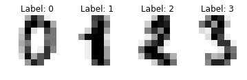

```python
for i in range(4):
    plt.subplot(1, 4, i + 1)
    plt.axis('off')
    plt.imshow(images[i], cmap=plt.cm.gray_r, interpolation='nearest')
    plt.title('Label: %i' % labels[i])
```

```python
C = 0.01
my_linear_classifier = SVC(kernel='linear', C=C).fit(features, labels)
```

```python
predicted_labels = my_linear_classifier.predict(features)
print "accuracy of the linear classifier: ", metrics.accuracy_score(labels, predicted_labels)
```

```
accuracy of the linear classifier:  0.999443516973
```

```python
print my_linear_classifier
```

```
SVC(C=0.01, cache_size=200, class_weight=None, coef0=0.0,
  decision_function_shape=None, degree=3, gamma='auto', kernel='linear',
  max_iter=-1, probability=False, random_state=None, shrinking=True,
  tol=0.001, verbose=False)
```

```python
features_train, features_test, labels_train, labels_test = train_test_split(features, labels, test_size = 0.5)
my_linear_classifier = SVC(kernel='rbf', C=C).fit(features_train, labels_train)
predicted_labels_train = my_linear_classifier.predict(features_train)
print "accuracy of the linear classifier: ", metrics.accuracy_score(labels_train, predicted_labels_train)
predicted_labels_test = my_linear_classifier.predict(features_test)
print "accuracy of the linear classifier: ", metrics.accuracy_score(labels_test, predicted_labels_test)
```

```
accuracy of the linear classifier:  0.114699331849
accuracy of the linear classifier:  0.0889877641824
```